# L12Ex_Voltage_Drop_Rick_Davila

Rick Davila

5/24/2020

#### Perform data housekeeping - upload, name columns, display to make sure it reads properly, etc.

```r
knitr::opts_chunk$set(echo = TRUE)

library(e1071)
library("xlsx")
library(xtable)
library(MASS) # Needed for ginv() function

rm(list = ls())

# load data
Ex72 <- read.xlsx(
  "data-ex-7-2.xlsx",
  sheetIndex = 1, sheetName=NULL, rowIndex=NULL,
  startRow=NULL, endRow=NULL, colIndex= c(1,2,3),
  as.data.frame=TRUE, header=TRUE, colClasses=NA,
  keepFormulas=FALSE, encoding="unknown")

# Give labels to data columns
names(Ex72) <- c("obs",
                 "time",
                 "voltage_drop")
attach(Ex72)

# Output data to make sure it reads properly
out <- as.data.frame(c(Ex72))
colnames(out) <- c("obs",
                 "time",
                 "voltage_drop")
tab <- (xtable(out, digits=c(0,0,1,2)))
print(tab, type="html")
```

|  | obs | time | voltage_drop |
| --- | --- | --- | --- |
| 1 | 1 | 0.0 | 8.33 |
| 2 | 2 | 0.5 | 8.23 |
| 3 | 3 | 1.0 | 7.17 |
| 4 | 4 | 1.5 | 7.14 |
| 5 | 5 | 2.0 | 7.31 |
| 6 | 6 | 2.5 | 7.60 |
| 7 | 7 | 3.0 | 7.94 |
| 8 | 8 | 3.5 | 8.30 |
| 9 | 9 | 4.0 | 8.76 |
| 10 | 10 | 4.5 | 8.71 |
| 11 | 11 | 5.0 | 9.71 |
| 12 | 12 | 5.5 | 10.26 |
| 13 | 13 | 6.0 | 10.91 |
| 14 | 14 | 6.5 | 11.67 |
| 15 | 15 | 7.0 | 11.76 |
| 16 | 16 | 7.5 | 12.81 |
| 17 | 17 | 8.0 | 13.30 |
| 18 | 18 | 8.5 | 13.88 |
| 19 | 19 | 9.0 | 14.59 |
| 20 | 20 | 9.5 | 14.05 |
| 21 | 21 | 10.0 | 14.48 |
| 22 | 22 | 10.5 | 14.92 |
| 23 | 23 | 11.0 | 14.37 |
| 24 | 24 | 11.5 | 14.63 |
| 25 | 25 | 12.0 | 15.18 |
| 26 | 26 | 12.5 | 14.51 |
| 27 | 27 | 13.0 | 14.34 |
| 28 | 28 | 13.5 | 13.81 |
| 29 | 29 | 14.0 | 13.79 |
| 30 | 30 | 14.5 | 13.05 |
| 31 | 31 | 15.0 | 13.04 |
| 32 | 32 | 15.5 | 12.60 |
| 33 | 33 | 16.0 | 12.05 |
| 34 | 34 | 16.5 | 11.15 |
| 35 | 35 | 17.0 | 11.15 |
| 36 | 36 | 17.5 | 10.14 |
| 37 | 37 | 18.0 | 10.08 |
| 38 | 38 | 18.5 | 9.78 |
| 39 | 39 | 19.0 | 9.80 |
| 40 | 40 | 19.5 | 9.95 |
| 41 | 41 | 20.0 | 9.51 |

```r
# Output data structure and dimensions
str(Ex72)
```

‘data.frame’: 41 obs. of 3 variables: $ obs : num 1 2 3 4 5 6 7 8 9 10 … $ time : num 0 0.5 1 1.5 2 2.5 3 3.5 4 4.5 … $ voltage_drop: num 8.33 8.23 7.17 7.14 7.31 7.6 7.94 8.3 8.76 8.71 …

```r
dim(Ex72)
```

[1] 41 3

## Example 7.2 (p.231-234)

#### Create scatterplot

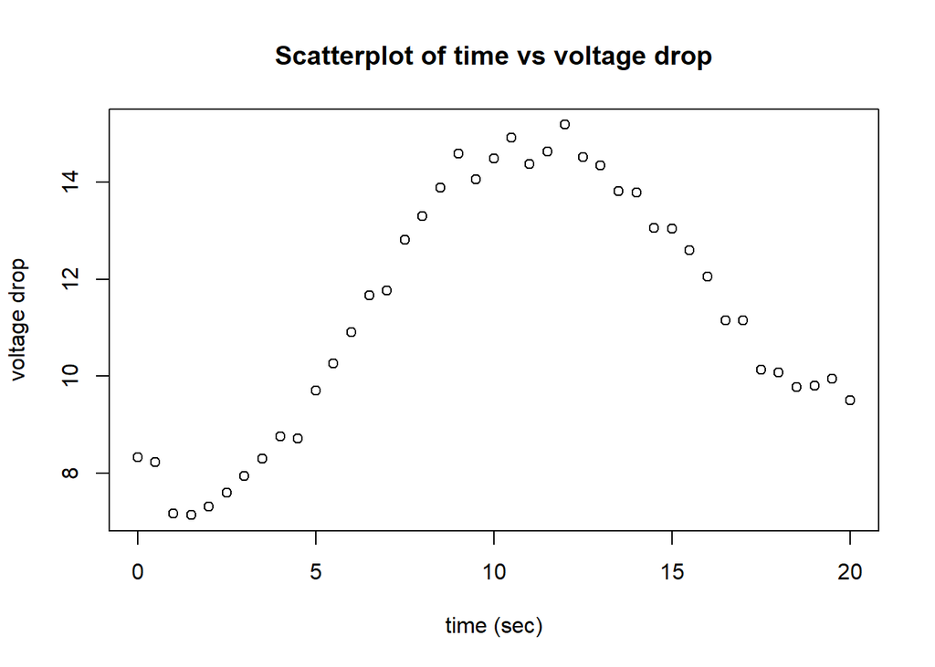

```r
plot(time, voltage_drop, main = "Scatterplot of time vs voltage drop",
     xlab = "time (sec)",
     ylab = "voltage drop")
```

## Fit a cubic spline using two knots, one at t1=6.5 and one at t2=13

#### Create indicator functions for the two knots

```r
t1 <- 6.5
t2 <- 13

x_t1 <- ifelse((time-t1)>0,(time-t1),0)
x_t2 <- ifelse((time-t2)>0,(time-t2),0)
```

#### Add columns to dataframe for the higher-order terms and spline terms

```r
Ex72$x_b01 <- time
Ex72$x_b02 <- time^2
Ex72$x_b03 <- time^3
Ex72$x_b1 <- x_t1^3
Ex72$x_b2 <- x_t2^3

# Output data to make sure it reads properly
out <- as.data.frame(c(Ex72))
#colnames(out) <- c("obs",
#                 "time",
#                 "voltage_drop")
tab <- (xtable(out, digits=c(0,0,1,2,3,3,3,3,3)))
print(tab, type="html")
```

|  | obs | time | voltage_drop | x_b01 | x_b02 | x_b03 | x_b1 | x_b2 |
| --- | --- | --- | --- | --- | --- | --- | --- | --- |
| 1 | 1 | 0.0 | 8.33 | 0.000 | 0.000 | 0.000 | 0.000 | 0.000 |
| 2 | 2 | 0.5 | 8.23 | 0.500 | 0.250 | 0.125 | 0.000 | 0.000 |
| 3 | 3 | 1.0 | 7.17 | 1.000 | 1.000 | 1.000 | 0.000 | 0.000 |
| 4 | 4 | 1.5 | 7.14 | 1.500 | 2.250 | 3.375 | 0.000 | 0.000 |
| 5 | 5 | 2.0 | 7.31 | 2.000 | 4.000 | 8.000 | 0.000 | 0.000 |
| 6 | 6 | 2.5 | 7.60 | 2.500 | 6.250 | 15.625 | 0.000 | 0.000 |
| 7 | 7 | 3.0 | 7.94 | 3.000 | 9.000 | 27.000 | 0.000 | 0.000 |
| 8 | 8 | 3.5 | 8.30 | 3.500 | 12.250 | 42.875 | 0.000 | 0.000 |
| 9 | 9 | 4.0 | 8.76 | 4.000 | 16.000 | 64.000 | 0.000 | 0.000 |
| 10 | 10 | 4.5 | 8.71 | 4.500 | 20.250 | 91.125 | 0.000 | 0.000 |
| 11 | 11 | 5.0 | 9.71 | 5.000 | 25.000 | 125.000 | 0.000 | 0.000 |
| 12 | 12 | 5.5 | 10.26 | 5.500 | 30.250 | 166.375 | 0.000 | 0.000 |
| 13 | 13 | 6.0 | 10.91 | 6.000 | 36.000 | 216.000 | 0.000 | 0.000 |
| 14 | 14 | 6.5 | 11.67 | 6.500 | 42.250 | 274.625 | 0.000 | 0.000 |
| 15 | 15 | 7.0 | 11.76 | 7.000 | 49.000 | 343.000 | 0.125 | 0.000 |
| 16 | 16 | 7.5 | 12.81 | 7.500 | 56.250 | 421.875 | 1.000 | 0.000 |
| 17 | 17 | 8.0 | 13.30 | 8.000 | 64.000 | 512.000 | 3.375 | 0.000 |
| 18 | 18 | 8.5 | 13.88 | 8.500 | 72.250 | 614.125 | 8.000 | 0.000 |
| 19 | 19 | 9.0 | 14.59 | 9.000 | 81.000 | 729.000 | 15.625 | 0.000 |
| 20 | 20 | 9.5 | 14.05 | 9.500 | 90.250 | 857.375 | 27.000 | 0.000 |
| 21 | 21 | 10.0 | 14.48 | 10.000 | 100.000 | 1000.000 | 42.875 | 0.000 |
| 22 | 22 | 10.5 | 14.92 | 10.500 | 110.250 | 1157.625 | 64.000 | 0.000 |
| 23 | 23 | 11.0 | 14.37 | 11.000 | 121.000 | 1331.000 | 91.125 | 0.000 |
| 24 | 24 | 11.5 | 14.63 | 11.500 | 132.250 | 1520.875 | 125.000 | 0.000 |
| 25 | 25 | 12.0 | 15.18 | 12.000 | 144.000 | 1728.000 | 166.375 | 0.000 |
| 26 | 26 | 12.5 | 14.51 | 12.500 | 156.250 | 1953.125 | 216.000 | 0.000 |
| 27 | 27 | 13.0 | 14.34 | 13.000 | 169.000 | 2197.000 | 274.625 | 0.000 |
| 28 | 28 | 13.5 | 13.81 | 13.500 | 182.250 | 2460.375 | 343.000 | 0.125 |
| 29 | 29 | 14.0 | 13.79 | 14.000 | 196.000 | 2744.000 | 421.875 | 1.000 |
| 30 | 30 | 14.5 | 13.05 | 14.500 | 210.250 | 3048.625 | 512.000 | 3.375 |
| 31 | 31 | 15.0 | 13.04 | 15.000 | 225.000 | 3375.000 | 614.125 | 8.000 |
| 32 | 32 | 15.5 | 12.60 | 15.500 | 240.250 | 3723.875 | 729.000 | 15.625 |
| 33 | 33 | 16.0 | 12.05 | 16.000 | 256.000 | 4096.000 | 857.375 | 27.000 |
| 34 | 34 | 16.5 | 11.15 | 16.500 | 272.250 | 4492.125 | 1000.000 | 42.875 |
| 35 | 35 | 17.0 | 11.15 | 17.000 | 289.000 | 4913.000 | 1157.625 | 64.000 |
| 36 | 36 | 17.5 | 10.14 | 17.500 | 306.250 | 5359.375 | 1331.000 | 91.125 |
| 37 | 37 | 18.0 | 10.08 | 18.000 | 324.000 | 5832.000 | 1520.875 | 125.000 |
| 38 | 38 | 18.5 | 9.78 | 18.500 | 342.250 | 6331.625 | 1728.000 | 166.375 |
| 39 | 39 | 19.0 | 9.80 | 19.000 | 361.000 | 6859.000 | 1953.125 | 216.000 |
| 40 | 40 | 19.5 | 9.95 | 19.500 | 380.250 | 7414.875 | 2197.000 | 274.625 |
| 41 | 41 | 20.0 | 9.51 | 20.000 | 400.000 | 8000.000 | 2460.375 | 343.000 |

#### Fit model; compare to values in Table 7.4, p. 233

```r
model.72 <- lm(voltage_drop ~
                 Ex72$x_b01 +
                 Ex72$x_b02 +
                 Ex72$x_b03 +
                 Ex72$x_b1 +
                 Ex72$x_b2)

summary(model.72)
```

Call: lm(formula = voltage_drop ~ Ex72$x_b01 + Ex72$x_b02 + Ex72$x_b03 + Ex72$x_b1 + Ex72$x_b2)

Residuals: Min 1Q Median 3Q Max -0.45168 -0.18499 -0.03547 0.20577 0.61694

Coefficients: Estimate Std. Error t value Pr(>|t|)  
(Intercept) 8.465678 0.200520 42.219 < 2e-16 *Ex72$x_b01 -1.453124 0.181586 -8.002 2.04e-09 *** Ex72$x_b02 0.489889 0.043018 11.388 2.54e-13* Ex72$x_b03 -0.029467 0.002848 -10.347 3.44e-12 *** Ex72$x_b1 0.024706 0.004039 6.116 5.43e-07 *Ex72$x_b2 0.027112 0.003578 7.577 6.98e-09* — Signif. codes: 0 ‘**’ 0.001 ’**’ 0.01 ’’ 0.05 ‘.’ 0.1 ’ ’ 1

Residual standard error: 0.2678 on 35 degrees of freedom Multiple R-squared: 0.9904, Adjusted R-squared: 0.9891 F-statistic: 725.5 on 5 and 35 DF, p-value: < 2.2e-16

```r
xtable(summary(model.72))
```

|  | Estimate | Std. Error | t value | Pr(>\|t\|) |
| --- | --- | --- | --- | --- |
| (Intercept) | 8.46567813 | 0.200519766 | 42.218672 | 1.292813e-31 |
| Ex72$x_b01 | -1.45312398 | 0.181586270 | -8.002389 | 2.041364e-09 |
| Ex72$x_b02 | 0.48988886 | 0.043017866 | 11.388033 | 2.542202e-13 |
| Ex72$x_b03 | -0.02946712 | 0.002847800 | -10.347331 | 3.443568e-12 |
| Ex72$x_b1 | 0.02470600 | 0.004039269 | 6.116454 | 5.425314e-07 |
| Ex72$x_b2 | 0.02711180 | 0.003578004 | 7.577352 | 6.980038e-09 |

#### Reproduce ANOVA table on p. 233

```r
summary(model.72)
```

Call: lm(formula = voltage_drop ~ Ex72$x_b01 + Ex72$x_b02 + Ex72$x_b03 + Ex72$x_b1 + Ex72$x_b2)

Residuals: Min 1Q Median 3Q Max -0.45168 -0.18499 -0.03547 0.20577 0.61694

Coefficients: Estimate Std. Error t value Pr(>|t|)  
(Intercept) 8.465678 0.200520 42.219 < 2e-16 *Ex72$x_b01 -1.453124 0.181586 -8.002 2.04e-09 *** Ex72$x_b02 0.489889 0.043018 11.388 2.54e-13* Ex72$x_b03 -0.029467 0.002848 -10.347 3.44e-12 *** Ex72$x_b1 0.024706 0.004039 6.116 5.43e-07 *Ex72$x_b2 0.027112 0.003578 7.577 6.98e-09* — Signif. codes: 0 ‘**’ 0.001 ’**’ 0.01 ’’ 0.05 ‘.’ 0.1 ’ ’ 1

Residual standard error: 0.2678 on 35 degrees of freedom Multiple R-squared: 0.9904, Adjusted R-squared: 0.9891 F-statistic: 725.5 on 5 and 35 DF, p-value: < 2.2e-16

```r
xtable(anova(model.72))
```

|  | Df | Sum Sq | Mean Sq | F value | Pr(>F) |
| --- | --- | --- | --- | --- | --- |
| Ex72$x_b01 | 1 | 48.162914 | 48.16291361 | 671.52626 | 1.989173e-24 |
| Ex72$x_b02 | 1 | 170.493247 | 170.49324703 | 2377.15463 | 9.097170e-34 |
| Ex72$x_b03 | 1 | 11.788218 | 11.78821797 | 164.36086 | 8.785188e-15 |
| Ex72$x_b1 | 1 | 25.615992 | 25.61599208 | 357.15886 | 6.047372e-20 |
| Ex72$x_b2 | 1 | 4.117984 | 4.11798435 | 57.41627 | 6.980038e-09 |
| Residuals | 35 | 2.510255 | 0.07172156 | NA | NA |

#### Test significance of spline terms using Partial F-test. Use alpha = 0.01 as the significance level

```r
# full model including spline terms
model.full <- lm(voltage_drop ~
                 Ex72$x_b01 +
                 Ex72$x_b02 +
                 Ex72$x_b03 +
                 Ex72$x_b1 +
                 Ex72$x_b2)

# reduced model excluding spline terms
model.reduced <- lm(voltage_drop ~
                 Ex72$x_b01 +
                 Ex72$x_b02 +
                 Ex72$x_b03)

# anova -- comparision of reduced to full model
anova(model.reduced, model.full)
```

|  | Res.Df | RSS | Df | Sum of Sq | F | Pr(>F) |
| --- | --- | --- | --- | --- | --- | --- |
| 1 | 37 | 32.244231 | NA | NA | NA | NA |
| 2 | 35 | 2.510255 | 2 | 29.73398 | 207.2876 | 3.955041e-20 |

```r
# F crit
alpha <- 0.01
df_SS_R <- anova(model.reduced, model.full)$'Df'[2]
df_SS_Res <- anova(model.reduced, model.full)$'Res.Df'[2]

F_crit <- qf(1-alpha,df_SS_R,df_SS_Res)
```

We’re investigating the contribution of the spline terms to the model. That is, we wish to test
$$H_0: \beta_1=\beta_2=0$$
we have
$$F_0 = \frac{SS_R(\beta_1,\beta_2|\beta_{00},\beta_{01},\beta_{02},\beta_{03}/2}{MS_{Res}}=\frac{29.7339764/2}{0.0717216}=207.2875639$$
and since $F_{0.01,2,35} = 5.2679413$, we have $F_0 \gt F_{0.01,2,35}$ and as a result, we reject the null hypothesis and conclude that the spline terms contributes significantly to the model.

#### Create residuals versus fits plot for each model

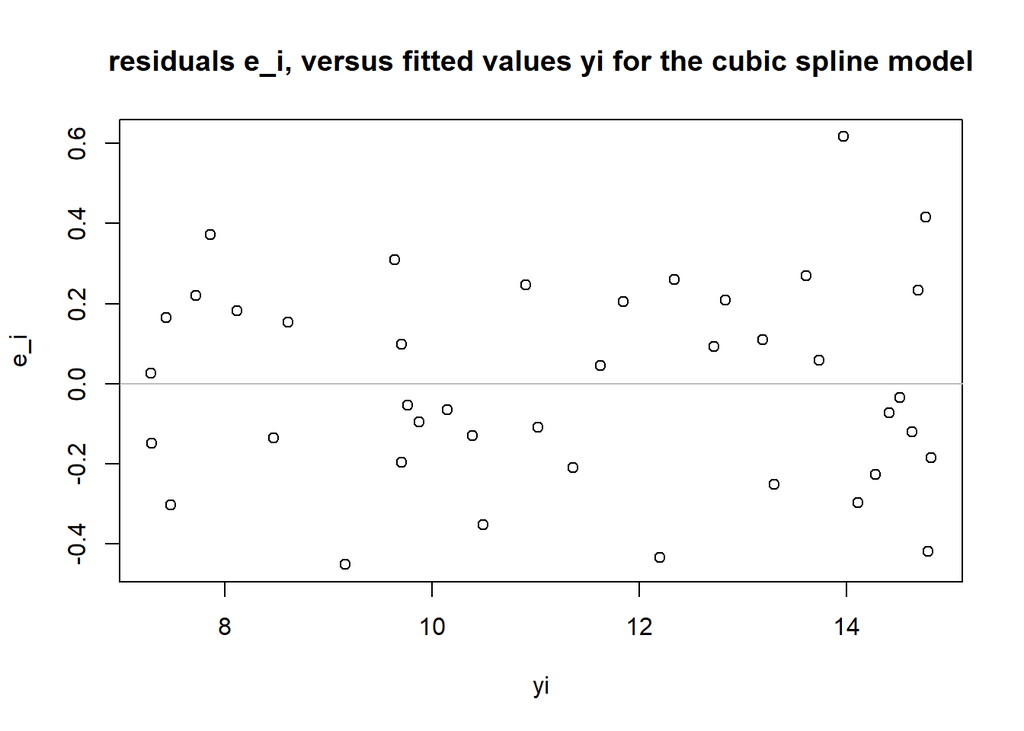

```r
plot(model.72$fitted.values, model.72$residuals, main = "residuals e_i, versus fitted values ŷi for the cubic spline model", xlab = "ŷi", ylab = "e_i")
abline(0, 0, col = "gray")
```

```r
# assumption, for the second model, like in the book, is to fit a cubic polynomial model and show a residuals versus fits plot

x_b01b <- time
x_b02b <- time^2
x_b03b <- time^3

model.72b <- lm(voltage_drop ~
                 x_b01b +
                 x_b02b +
                 x_b03b)

summary(model.72b)
```

```
##
## Call:
## lm(formula = voltage_drop ~ x_b01b + x_b02b + x_b03b)
##
## Residuals:
##     Min      1Q  Median      3Q     Max
## -1.3503 -0.7340 -0.1859  0.6440  1.8390
##
## Coefficients:
##               Estimate Std. Error t value Pr(>|t|)
## (Intercept)  6.4910163  0.5336473  12.163 1.71e-14 ***
## x_b01b       0.7031952  0.2339552   3.006 0.004738 **
## x_b02b       0.0340179  0.0273762   1.243 0.221829
## x_b03b      -0.0033072  0.0008992  -3.678 0.000743 ***
## ---
## Signif. codes:  0 '***' 0.001 '**' 0.01 '*' 0.05 '.' 0.1 ' ' 1
##
## Residual standard error: 0.9335 on 37 degrees of freedom
## Multiple R-squared:  0.8773, Adjusted R-squared:  0.8673
## F-statistic: 88.14 on 3 and 37 DF,  p-value: < 2.2e-16
```

```r
xtable(summary(model.72b))
```

|  | Estimate | Std. Error | t value | Pr(>\|t\|) |
| --- | --- | --- | --- | --- |
| (Intercept) | 6.491016346 | 0.5336472749 | 12.163496 | 1.705415e-14 |
| x_b01b | 0.703195219 | 0.2339551713 | 3.005684 | 4.738282e-03 |
| x_b02b | 0.034017947 | 0.0273761684 | 1.242612 | 2.218288e-01 |
| x_b03b | -0.003307211 | 0.0008992137 | -3.677892 | 7.431685e-04 |

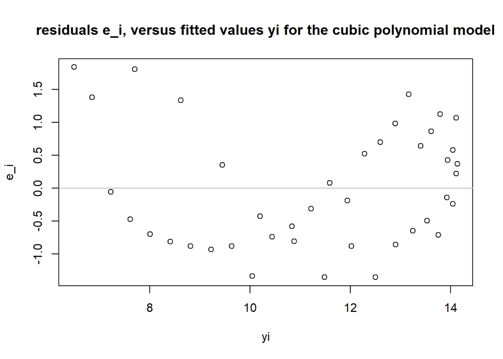

```r
plot(model.72b$fitted.values, model.72b$residuals, main = "residuals e_i, versus fitted values ŷi for the cubic polynomial model", xlab = "ŷi", ylab = "e_i")
abline(0, 0, col = "gray")
```